# Summary

The primary question of the Room Key Data Challenge was:

> What factors correlate with users booking and in turn, what can Room Key do to increase booking conversion rate?

The work that I did is contained in the following notebooks:

- Data Details
- Exploratory Data Analysis
- Variable Importance via Random Forest

In the Data Details notebook, I worked through importing and cleaning the data and I did some initial exploration of the data to get a sense of what each variable contained. The Exploratory Data Analysis notebook digs deeper into each variable in the data set and attempts to either visualize or calculate trends in the data. The notebook on Variable Importance via Random Forest details an exploration of different ways to train a random forest model to determine what variables correlate with users booking.

The bulk of the work was done in the Exploratory Data Analysis and Variable Importance via Random Forest notebooks. This notebook will contain a summary of my work, highlighting the key results. For information on my process and all of the steps taken to reach these results, please see the individual notebooks.

```r
library(tidyverse)
library(jsonlite)
library(caret)
report_theme <- ggplot2::theme_bw() +
  ggplot2::theme(panel.border = ggplot2::element_rect(color = "black",
                                                      fill = NA),
                 panel.grid.major = ggplot2::element_line(color = "black",
                                                          linetype = "dotted"),
                 panel.grid.minor = ggplot2::element_line(color = "black",
                                                          linetype = "dotted"))
lead_ref <- read_csv("lead_ref_data.csv", progress = FALSE)
```

# What variables correlate with booking?

My first step was to examine the data for obvious trends. Though no major trends popped out, one fairly useful trend appeared. I created an additional variable that gave whether a user left the website to a hotel partner that was the same as the referring hotel partner. This appeared to show that a much larger proportion of users booked a hotel when they left the site to a hotel of that same partner, as opposed to a different partner.

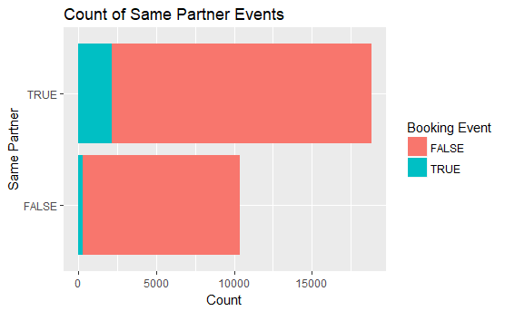

```r
lead_ref %>%
  mutate(same_partner = (partner_code_referral == rate_partner_lead)) %>%
  filter(!is.na(same_partner)) %>%
  ggplot(aes(x = same_partner, fill = booking_event)) +
  geom_bar() +
  coord_flip() +
  ggtitle("Count of Same Partner Events") +
  labs(y = "Count",
       x = "Same Partner",
       fill = "Booking Event")
```

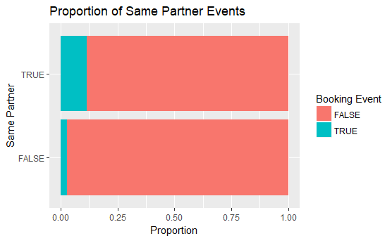

```r
lead_ref %>%
  mutate(same_partner = (partner_code_referral == rate_partner_lead)) %>%
  filter(!is.na(same_partner)) %>%
  ggplot(aes(x = same_partner, fill = booking_event)) +
  geom_bar(position = "fill") +
  coord_flip() +
  ggtitle("Proportion of Same Partner Events") +
  labs(y = "Proportion",
       x = "Same Partner",
       fill = "Booking Event")
```

My next step was to try calculating the correlation between the variables and the booking events. I found that for all of the numerical variables, the correlation was either incredibly small or non-existent. For the categorical variables I used a chi-square test that showed a high significance of variability, but gave little information on how those variables influenced the booking events.

To determine which variables had the greatest impact on booking, I decided to train a random forest model with the data and calculate the importance of the different variables to the model.

# Random Forest

I went through many different iterations of the random forest algorithm, trying different sets of variables, different metrics for optimizing the hyperparameters, and different types of sampling. Many of the initial attempts at training a random forest model produced a high accuracy (approximately 90%), but a close to 0% sensitivity (true positive rate).

Since the quantity that we are interested in is the true positive rate (rate of leads converted to bookings), I wanted to make some changes. The first major change I made was switching the metric for training the hyperparameters from Accuracy (the sum of true positives and true negatives divided by the total number of observations) to Kappa, which is slightly more robust for an unbalanced data set.

When this did not produce a reasonable model, I turned to sampling to solve the problem of an unbalanced data set. I tested several different sampling methods for the random forest training including over-sampling and under-sampling. I also made use of the ROSE and SMOTE methods available from the `caret` package. Of these four methods, under-sampling returned the highest sensitivity and accuracy for a relatively short computation time. Minimized below is a sample of the code used to train the random forest model. In the code shown below are also some data modification steps where some of the variables are transformed. One of the major transformations done was reducing the number of categories for the rate partner variables. I kept the 4 partners with the highest number of events and put the other partners into a single group titled “Other”.

```r
data_for_model <- lead_ref %>%
  select(booking_event,
         ts_referral,
         ts_lead,
         check_in_diff,
         check_out_diff,
         partner_code_referral,
         rate_partner_lead) %>%
  filter(!is.na(ts_referral)) %>%
  filter(!is.na(partner_code_referral)) %>%
  filter(!is.na(check_in_diff)) %>%
  filter(!is.na(check_out_diff)) %>%
  mutate(time_diff = ts_lead - ts_referral) %>%
  mutate(booking_event = factor(booking_event, levels = c("TRUE", "FALSE")))
rename_referral_partner <- data_for_model %>%
  group_by(partner_code_referral) %>%
  count() %>%
  arrange(desc(n)) %>%
  ungroup() %>%
  rownames_to_column() %>%
  mutate(rowname = as.numeric(rowname)) %>%
  mutate(new_referral_partner = ifelse(rowname < 5, partner_code_referral, "Other")) %>%
  select(partner_code_referral, new_referral_partner)
rename_lead_partner <- data_for_model %>%
  group_by(rate_partner_lead) %>%
  count() %>%
  arrange(desc(n)) %>%
  ungroup() %>%
  rownames_to_column() %>%
  mutate(rowname = as.numeric(rowname)) %>%
  mutate(new_lead_partner = ifelse(rowname < 5, rate_partner_lead, "Other")) %>%
  select(rate_partner_lead, new_lead_partner)
modified_data_for_model <- data_for_model %>%
  left_join(rename_referral_partner, by = "partner_code_referral") %>%
  left_join(rename_lead_partner, by = "rate_partner_lead") %>%
  select(-partner_code_referral, -rate_partner_lead) %>%
  mutate(same_partner = (new_referral_partner == new_lead_partner)) %>%
  mutate(new_referral_partner = factor(new_referral_partner)) %>%
  mutate(new_lead_partner = factor(new_lead_partner)) %>%
  mutate(same_partner = factor(same_partner, levels = c("TRUE", "FALSE")))
set.seed(85)
train_index <- createDataPartition(modified_data_for_model$booking_event,
                            p = 0.8,
                            list = FALSE,
                            times = 1)
training <- modified_data_for_model[train_index, ]
testing <- modified_data_for_model[-train_index, ]
train_independent <- training %>%
  select(-booking_event) %>%
  as.data.frame()
train_dependent <- training %>%
  select(booking_event)
set.seed(85)
# rf_model_under <- train(x = train_independent,
#                   y = train_dependent$booking_event,
#       method = "ranger",
#       trControl = trainControl(method = "repeatedcv",
#                                number = 10,
#                                repeats = 10,
#                                sampling = "down"),
#       importance = "permutation",
#       metric = "Kappa")
```

From that random forest model, we can make some predictions using a testing set that was separated from the training data set. The results of the predictions can be shown as a confusion matrix with some additional summary statistics.

```r
rf_prediction_under <- predict(rf_model_under, testing[, -1])
(cm_under <- confusionMatrix(rf_prediction_under, testing$booking_event))
```

```
Confusion Matrix and Statistics

          Reference
Prediction TRUE FALSE
     TRUE   318  1997
     FALSE  103  2548

               Accuracy : 0.5771
                 95% CI : (0.5632, 0.5909)
    No Information Rate : 0.9152
    P-Value [Acc > NIR] : 1

                  Kappa : 0.1039
 Mcnemar's Test P-Value : <2e-16

            Sensitivity : 0.75534
            Specificity : 0.56062
         Pos Pred Value : 0.13737
         Neg Pred Value : 0.96115
             Prevalence : 0.08478
         Detection Rate : 0.06404
   Detection Prevalence : 0.46617
      Balanced Accuracy : 0.65798

       'Positive' Class : TRUE
```

This confusion matrix shows the approximately 76% sensitivity with an accuracy of about 58%. While this model has a fairly large number of false positives, it does pick out some of the important information from the data set.

# Variable Importance

Now that I have trained a random forest model on the data set, I can extract which of the variables were the most important. I tried this using two different methods. One is the built in method for the random forest implementation in R where the difference in accuracies for the random forest model and the model under a permutation of the variables is used. The other method I used is the default of the `caret` package where the area under the ROC curve is used.

```r
varImp(rf_model_under, scale = FALSE)
```

```
ranger variable importance

                      Overall
same_partner         0.042322
new_lead_partner     0.037286
new_referral_partner 0.020110
check_out_diff       0.020110
ts_referral          0.020097
ts_lead              0.019572
check_in_diff        0.014845
time_diff            0.001383
```

```r
varImp(rf_model_under, useModel = FALSE, scale = FALSE)
```

```
ROC curve variable importance

                     Importance
same_partner             0.6304
new_lead_partner         0.5687
time_diff                0.5662
ts_lead                  0.5592
ts_referral              0.5589
check_out_diff           0.5394
check_in_diff            0.5361
new_referral_partner     0.5179
```

Both of these methods give the `same_partner` and `new_lead_partner` variables as the most important. I tested this by training the random forest model again, but removing one or both of the variables and comparing the sensitivity and accuracy. Removing those variable led to a drop in the sensitivity to approximately 62%. I also tested models that were trained with the less important variables removed. Those models returned a sensitivity in the 80% range, but also led to a decrease in specificity (an increase in the false positive rate).

The results from these models indicate that the `new_lead_partner` variable and the `same_partner` variable are the two most important factors in the model.

# Recommendations

Given the results of the random forest model training, there are several suggestions that I can make. Most of the recommendations are for further testing to determine how the `same_partner` and `new_lead_partner` variables can be manipulated to produce a higher booking rate.

First, I would suggest running a test on the `same_partner` variable. This test could examine the response of users that only receive hotel suggestions that are the same as the referring partner compared to those that receive the normal suggestions produced by the website. A similar test could be done looking at users that only receive hotel suggestions that are not from the referring partner.

My other recommendation would be to have a discussion with the engineers on what type of data can be additionally collected. These models are still fairly low on accuracy and additional information on the users could help make the models better.

Of course, this is all dependent on the capabilities of the website and could be further refined with discussions with the engineers.

# Further Work

In addition to the recommendations, there are few things that I think could be a way forward from the data science side.

First, there may be a better algorithm than the random forest model at handling the unbalanced classification problem that this data set presents. I would recommend trying a number of different models and comparing them to the performance of the random forest to see if better accuracy and sensitivity is possible with this data.

Another piece of further work would be finding a way to categorize the `location_tid` and `udicode` variables for use within the model. In the random forest models that I presented above, those two variables were excluded due to the large number of categories present within the variables. Finding a way to include them within the model could help to increase the sensitivity of the model.